# Homework 5

Caden Zonnefeld

11 April 2020

## Question 1

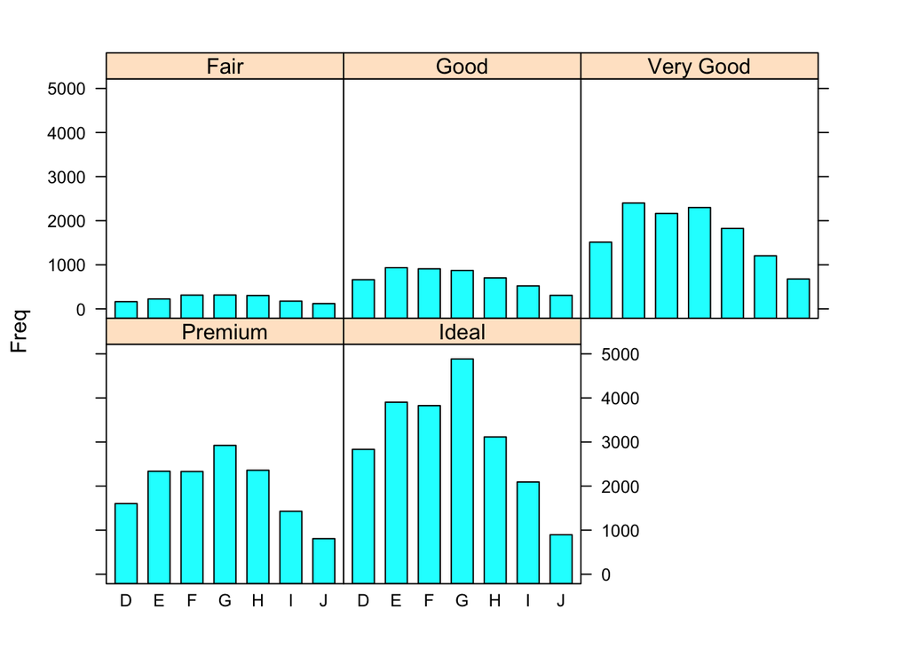

```r
library(ggplot2)
library(lattice)
ccfreq <- data.frame(xtabs(~cut+color,diamonds))
barchart(Freq~color|cut,ccfreq,as.table=TRUE)
```

## Question 2

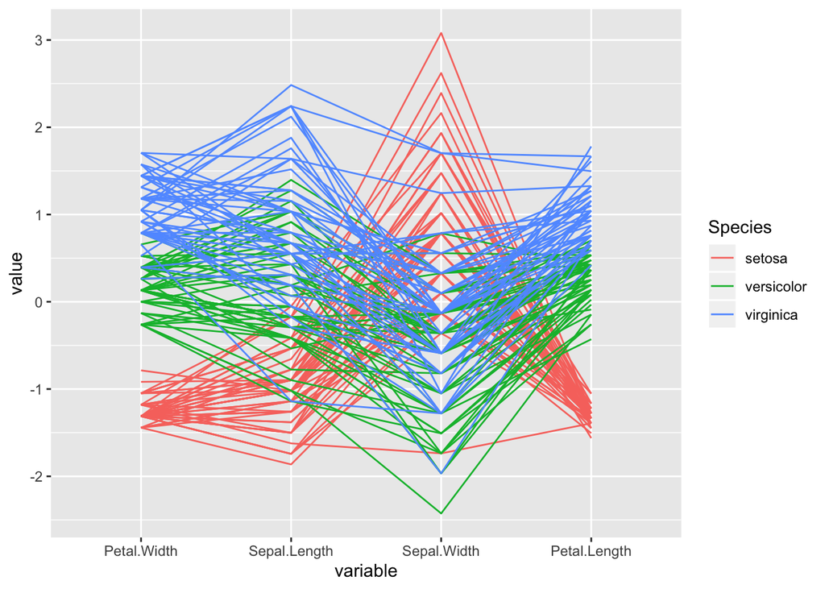

```r
library(GGally)
ggparcoord(iris,columns=c(4,1,2,3),groupColumn=5)
```

I switched the order of the parallel coordinates sutch that it is now in the order of: Petal.Width, Sepal.Length, Sepal.Width, and Petal.length. Though the numeric variables are now in a different order, the parallel coordinates tells a similar story. It is still clear that the Setosa has all of the smallest petal widths and lengths as well as most of the smallest sepal lengths. Furthermore, it is still clear that Setosa has the largest average sepal width. The parallel coordinates are once more clear in showing that Virginica tend to have the largest values of petal width and length (almost without exception), follwed by Versicolor and then Setosa. Likewise, Virginica appears to tend to have a slightly larger sepal length than Versicolor though the difference is less significant than that of petal width or length. The different order of the numeric variables reveals the same information from the data.

## Question 3

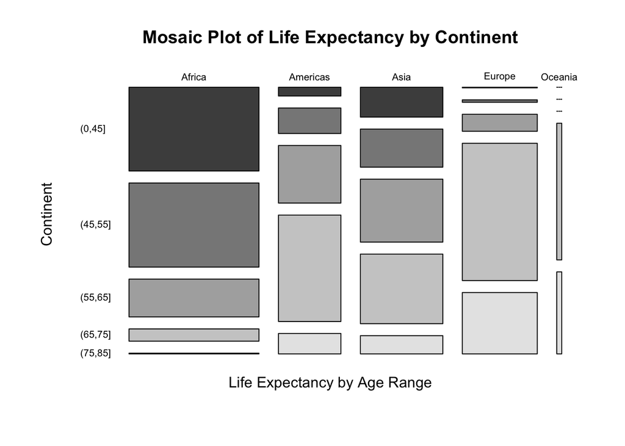

```r
library(gapminder)
lifeExpectancy <- cut(gapminder$lifeExp,breaks=c(0,45,55,65,75,85))
mosaicplot(~gapminder$continent+lifeExpectancy,off=18, xlab="Life Expectancy by Age Range", ylab="Continent", main="Mosaic Plot of Life Expectancy by Continent",color=TRUE,las=1)
```

I used a mosaic plot to compare life expectancies (by each range) by continent. I first used the cut function to separate life expectancy into bins and make it a categorical variable. The data shows that Oceania has the highest proportion of life expectancies that live oldest.The thin bars at the top of Oceania’s column indicate that there are very few life expectancies that fall in the (0,45], (45,55], or (55,65] life expectancy ranges. Conversely we can see that Africa has the highest proportion of life expectancies that fall in the lowest range, (0,45]. We can also see that there are few life expectancies in the (75,85] rannge from Africa. The greater width of Africa’s column shows that it has the most data entries; conversely, Oceania’s column is the thinnest indicating that it has the least data entries. I also used shading to further distinguish groups with lighter greys corresponding to longer life expectancies and darker greys corresponding to shorter life expectancies.

## Question 4

A pie chart represents the proportion that each variable accounts for of the whole. Polar diagrams function like bar charts in a polar coordinate plane. The square root is taken of each variable and is used to make the area of each wedge proportional to its magnitdue. In effect, the further that each wedge extends from the center of the polar diagram the larger proportion it accounts for. Pie charts depict proportion by the length of the arc around the circumference of the circle for each wedge, whereas polar diagrams depict proportion by outward extension of each wedge. I prefer pie charts as it is easier visually to percieve different proportions of each wedge by the length of an arc around a circle’s circumference (pie chart) than by the distance a wedge extends from the center of the circle (polar diagram).

## Question 5

A clustered bar graph can similarly present two categoricals with a numeric. With a clustered bar graph instead of each factor level being stacked (like the colors in the diamond stacked bar graph) each factor level is a column within each respective cluster such as cut quality for the diamond stacked bar graph example.

## Question 6

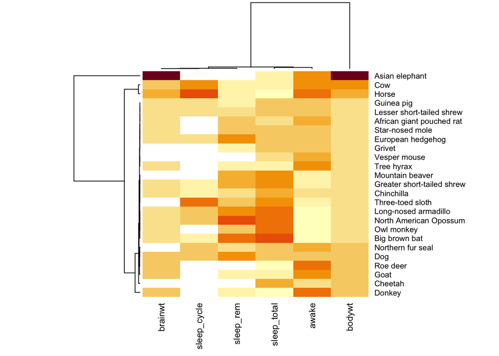

```r
library(ggplot2)
sleep <- msleep[c(6,7,8,9,10,11)]
sleep <- sleep[1:25,]
heatmap(as.matrix(sleep),labRow=msleep$name,cexRow=0.8,cexCol = 0.9, scale='column')
```